# Univariate spatial regression: Bartlett Experimental Forest (BEF) analysis

1. Load the libraries to be used

```r
library(sf)
library(terra)
library(raster)
library(spBayes)
library(MBA)
library(geoR)
library(fields)
```

```r
library(maptools)
library(classInt)
library(lattice)
```

```r
data(BEF.dat)
befDat <- BEF.dat[BEF.dat$ALLBIO02_KGH > 0, ]
bio <- befDat$ALLBIO02_KGH * 0.001
logBio <- log(bio)
```

3. Extract the coordinates

```r
befCoords <- as.matrix(befDat[, c("XUTM", "YUTM")])
```

4. Create a surface plot using the Multilevel B-spline Approximation (MBA).

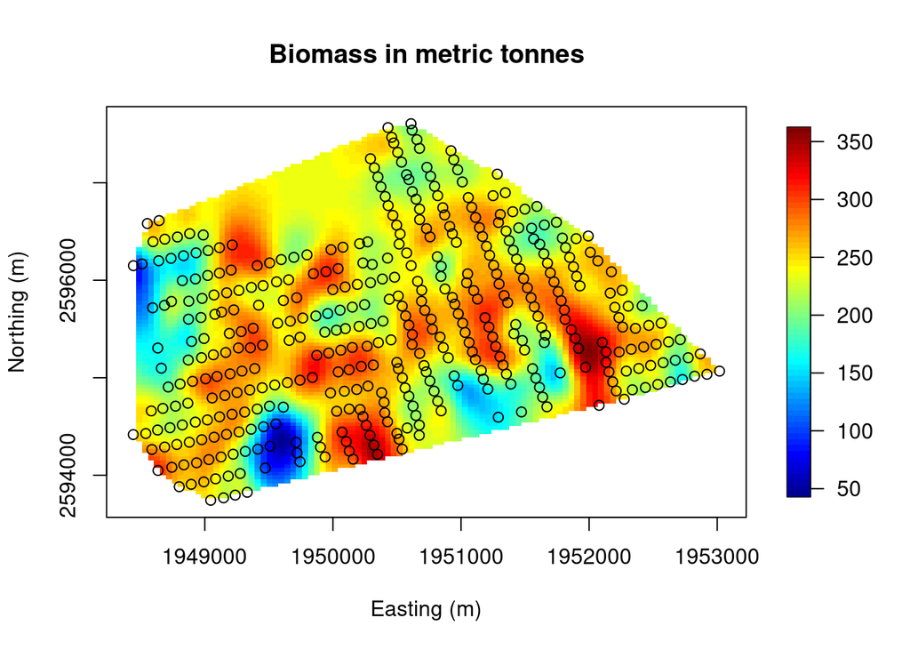

```r
xRes <- 100
yRes <- 100
surf <- mba.surf(cbind(befCoords, bio), no.X = xRes, no.Y = yRes, h = 5, m = 2, extend = FALSE)$xyz.est
image.plot(surf, xaxs = "r", yaxs = "r", xlab = "Easting (m)", ylab = "Northing (m)",
    main = "Biomass in metric tonnes")
points(befCoords)
```

5. Start with a simple Ordinary Least Squares (OLS) regression.

```r
model <- logBio ~ ELEV + SLOPE + SUM_02_TC1 + SUM_02_TC2 + SUM_02_TC3
modelFit <- lm(model, data = befDat)
modelFitSummary <- summary(modelFit)
print(modelFitSummary)  ##Print summary of classical OLS model fit
```

```
Call:
lm(formula = model, data = befDat)

Residuals:
     Min       1Q   Median       3Q      Max
-1.79092 -0.14262  0.04728  0.20521  0.67744

Coefficients:
              Estimate Std. Error t value Pr(>|t|)
(Intercept)  0.7534253  0.6812872   1.106 0.269426
ELEV         0.0006276  0.0001923   3.264 0.001190 **
SLOPE       -0.0104332  0.0029867  -3.493 0.000529 ***
SUM_02_TC1   0.0094663  0.0054483   1.737 0.083054 .
SUM_02_TC2   0.0068053  0.0035748   1.904 0.057649 .
SUM_02_TC3   0.0241059  0.0049732   4.847 1.78e-06 ***
---
Signif. codes:  0 '***' 0.001 '**' 0.01 '*' 0.05 '.' 0.1 ' ' 1

Residual standard error: 0.3166 on 409 degrees of freedom
Multiple R-squared:  0.1966,    Adjusted R-squared:  0.1868
F-statistic: 20.02 on 5 and 409 DF,  p-value: < 2.2e-16
```

```r
bioResid = resid(modelFit)  ##Store residuals from the OLS model fit for later use
```

6. Prepare for the Bayesian modeling. Extract the number of regression coefficients and create a flat non-informative prior for the regression coefficients.

```r
p <- length(coefficients(modelFit))  ## This is the number of columns in the design matrix
## Set the prior mean and precision for the regression
betaPriorMean <- as.matrix(rep(0, times = p))
betaPriorPrecision <- matrix(0, nrow = p, ncol = p)
```

7. Prepare the fixed inputs for “bayesGeostatExact” function.

```r
phi <- 0.014  ## Set the spatial range (from the variogram)
alpha <- 0.016/0.08  ## Set the nugget/partial-sill ratio
sigmaSqPriorShape <- 2  ## Set IG shape for sigma.sq (partial sill)
sigmaSqPriorRate <- 0.08  ## Set IG scale for sigma.sq (partial sill)
```

8. Run bayesGeostatExact to deliver exact posterior samples

```r
spExact <- bayesGeostatExact(model, data = befDat, coords = befCoords, n.samples = 1000,
    beta.prior.mean = betaPriorMean, beta.prior.precision = betaPriorPrecision, cov.model = "exponential",
    phi = phi, alpha = alpha, sigma.sq.prior.shape = sigmaSqPriorShape, sigma.sq.prior.rate = sigmaSqPriorRate,
    sp.effects = TRUE)
```

```
-------------------------------------------------
    General model description
-------------------------------------------------
Model fit with 415 observations.
Number of covariates 6 (including intercept if specified).
Using the exponential spatial correlation model.

-------------------------------------------------
        Sampling
-------------------------------------------------
Sampled: 1000 of 1000, 100%
-------------------------------------------------
    Recovering spatial effects
-------------------------------------------------
```

9. Produce the posterior summaries from “bayesGeostatExact”

```r
round(summary(spExact$p.samples)$quantiles, 3)
```

```
              2.5%    25%    50%    75%  97.5%
(Intercept) -0.403  0.623  1.199  1.721  2.737
ELEV         0.000  0.000  0.000  0.001  0.001
SLOPE       -0.016 -0.011 -0.009 -0.006 -0.001
SUM_02_TC1  -0.001  0.006  0.010  0.015  0.024
SUM_02_TC2  -0.002  0.003  0.006  0.009  0.013
SUM_02_TC3   0.010  0.017  0.021  0.025  0.033
sigma.sq     0.072  0.078  0.082  0.086  0.095
tau.sq       0.014  0.016  0.016  0.017  0.019
```

10. Run spLM to deliver MCMC samples from marginal posterior distributions

```r
nSamples <- 1000
befSp <- spLM(model, data = befDat, coords = befCoords, starting = list(phi = 3/200,
    sigma.sq = 0.08, tau.sq = 0.02), tuning = list(phi = 0.1, sigma.sq = 0.05, tau.sq = 0.05),
    priors = list(phi.Unif = c(3/1500, 3/50), sigma.sq.IG = c(2, 0.08), tau.sq.IG = c(2,
        0.02)), cov.model = "exponential", n.samples = nSamples)
```

```
----------------------------------------
    General model description
----------------------------------------
Model fit with 415 observations.

Number of covariates 6 (including intercept if specified).

Using the exponential spatial correlation model.

Number of MCMC samples 1000.

Priors and hyperpriors:
    beta flat.
    sigma.sq IG hyperpriors shape=2.00000 and scale=0.08000
    tau.sq IG hyperpriors shape=2.00000 and scale=0.02000
    phi Unif hyperpriors a=0.00200 and b=0.06000
-------------------------------------------------
        Sampling
-------------------------------------------------
Sampled: 100 of 1000, 10.00%
Report interval Metrop. Acceptance rate: 34.00%
Overall Metrop. Acceptance rate: 34.00%
-------------------------------------------------
Sampled: 200 of 1000, 20.00%
Report interval Metrop. Acceptance rate: 22.00%
Overall Metrop. Acceptance rate: 28.00%
-------------------------------------------------
Sampled: 300 of 1000, 30.00%
Report interval Metrop. Acceptance rate: 22.00%
Overall Metrop. Acceptance rate: 26.00%
-------------------------------------------------
Sampled: 400 of 1000, 40.00%
Report interval Metrop. Acceptance rate: 24.00%
Overall Metrop. Acceptance rate: 25.50%
-------------------------------------------------
Sampled: 500 of 1000, 50.00%
Report interval Metrop. Acceptance rate: 34.00%
Overall Metrop. Acceptance rate: 27.20%
-------------------------------------------------
Sampled: 600 of 1000, 60.00%
Report interval Metrop. Acceptance rate: 27.00%
Overall Metrop. Acceptance rate: 27.17%
-------------------------------------------------
Sampled: 700 of 1000, 70.00%
Report interval Metrop. Acceptance rate: 33.00%
Overall Metrop. Acceptance rate: 28.00%
-------------------------------------------------
Sampled: 800 of 1000, 80.00%
Report interval Metrop. Acceptance rate: 25.00%
Overall Metrop. Acceptance rate: 27.62%
-------------------------------------------------
Sampled: 900 of 1000, 90.00%
Report interval Metrop. Acceptance rate: 23.00%
Overall Metrop. Acceptance rate: 27.11%
-------------------------------------------------
Sampled: 1000 of 1000, 100.00%
Report interval Metrop. Acceptance rate: 24.00%
Overall Metrop. Acceptance rate: 26.80%
-------------------------------------------------
```

11. Produce the posterior summaries from “spLM”

```r
print(round(summary(befSp$p.theta.samples)$quantiles, 3))
```

```
          2.5%   25%   50%   75% 97.5%
sigma.sq 0.065 0.084 0.091 0.099 0.116
tau.sq   0.004 0.006 0.009 0.015 0.033
phi      0.008 0.011 0.012 0.013 0.018
```

12. Recover spatial residuals using “spRecover”

```r
burnIn <- floor(0.75 * nSamples)
befSp <- spRecover(befSp, start = burnIn, thin = 2)
```

```
-------------------------------------------------
        Recovering beta and w
-------------------------------------------------
Sampled: 99 of 126, 78.57%
```

13. The posterior samples of the regression coefficients and the spatial effects can then be obtained.

```r
betaSamples = befSp$p.beta.recover.samples
wSamples = befSp$p.w.recover.samples
```

14. Obtain trace plots for regression coefficients

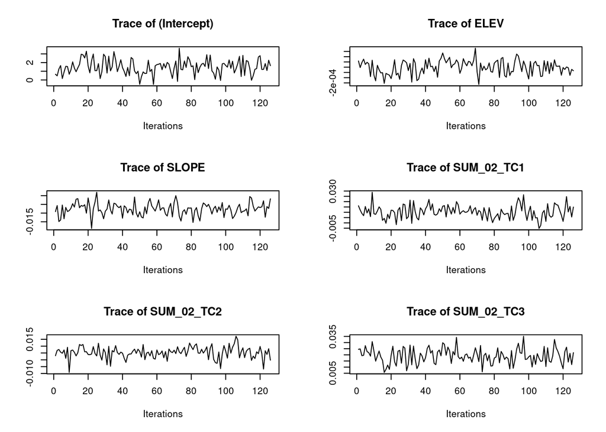

```r
par(mfrow = c(3, 2))
plot(betaSamples, auto.layout = TRUE, density = FALSE)
```

15. Obtain posterior means and sd’s of spatial residuals for each location

```r
wHatMu <- apply(wSamples, 1, mean)
wHatSd <- apply(wSamples, 1, sd)
```

16. Plot the OLS residual surface and a map of the posterior mean of spatial effects

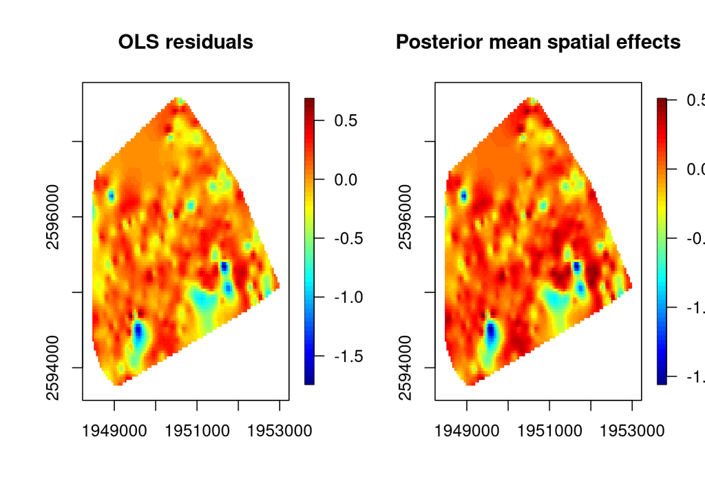

```r
par(mfrow = c(1, 2))
surfResid <- mba.surf(cbind(befCoords, bioResid), no.X = xRes, no.Y = yRes, extend = FALSE)$xyz.est
zLim <- range(surfResid[["z"]], na.rm = TRUE)
image.plot(surfResid, xaxs = "r", yaxs = "r", zlim = zLim, main = "OLS residuals")
surfSpatMean <- mba.surf(cbind(befCoords, wHatMu), no.X = xRes, no.Y = yRes, extend = FALSE)$xyz.est
zLim <- range(surfSpatMean[["z"]], na.rm = TRUE)
image.plot(surfSpatMean, xaxs = "r", yaxs = "r", zlim = zLim, main = "Posterior mean spatial effects")
```

17. Introduce a shapefile for a region of interest where we wish to interpolate. Read the shapefile.

```r
befShp <- st_read("../data/BEF-data/BEF_bound.shp")
```

18. Carry out spatial interpolation supervised by the points with observations

```r
surfOut <- mba.surf(cbind(befCoords, logBio), no.X = xRes, no.Y = yRes, extend = TRUE)$xyz.est
zLim <- range(surfOut[["z"]], na.rm = TRUE)
```

19. Map the interpolated values from MBA output

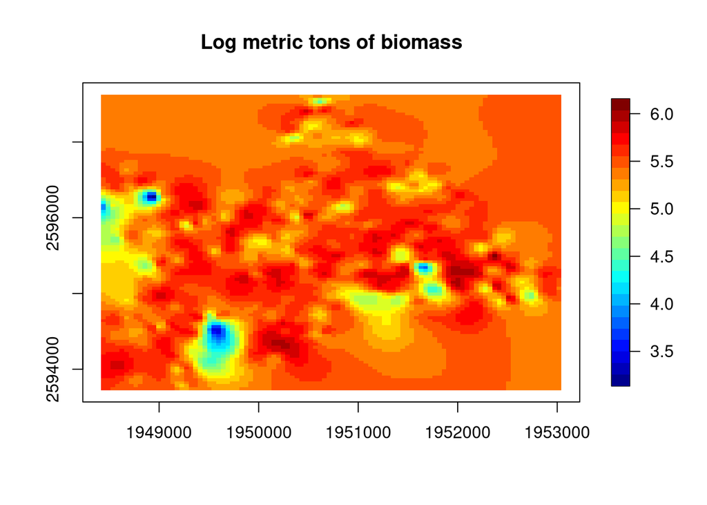

```r
image.plot(surfOut, axes = TRUE, zlim = zLim, col = tim.colors(25), xaxs = "r", yaxs = "r",
    main = "Log metric tons of biomass")
```

20. OPTIONAL: How to create a data frame with all grid point combinations

```r
gridCoords <- expand.grid(x = surfOut$x, y = surfOut$y)
interpolatedValues <- as.vector(surfOut$z)
surfDf <- cbind(gridCoords, z = interpolatedValues)
dim(surfDf)
```

```
[1] 10000     3
```

```r
head(surfDf)
```

```
        x       y        z
1 1948441 2593743 5.572710
2 1948488 2593743 5.565172
3 1948534 2593743 5.552159
4 1948580 2593743 5.532807
5 1948626 2593743 5.507243
6 1948673 2593743 5.480867
```

21. Here is how we can clip images to fit within a polygon from a shapefile

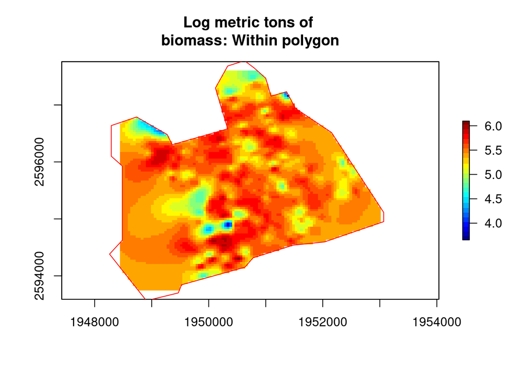

```r
surfOutRaster <- raster(surfOut$z, xmn = min(surfOut$x), xmx = max(surfOut$x), ymn = min(surfOut$y),
    ymx = max(surfOut$y))
surfOutClipped <- mask(surfOutRaster, befShp)
plot(surfOutClipped, col = tim.colors(25), xaxs = "r", yaxs = "r", main = "Log metric tons of
biomass: Within polygon")
# Optional Overlay the polygon boundary
plot(st_geometry(befShp), add = TRUE, border = "red")
```